# Отчет по проекту_3

### 0. Организационная часть

Список используемых в работе библиотек: **readxl**, **stringr**, **vegan**, **dplyr**, **ggplot2**, **factoextra**, **cowplot**, **car**, **multcomp**, **pca3d**, **gridExtra**.

Для работы необходимо задать путь до директории, содержащей распакованные файлы для работы над проектом:

```r
dir_path <- '/home/yulia/stat_and_r/'
```

Теперь можно подгружать данные:

```r
data <- read_excel(paste(dir_path, 'Data_Cortex_Nuclear.xls', sep = ''))
```

### Блок 1. Описание датасета

Знакомимся с данными:

```r
str(data)
```

```
## Classes 'tbl_df', 'tbl' and 'data.frame':    1080 obs. of  82 variables:
##  $ MouseID        : chr  "309_1" "309_2" "309_3" "309_4" ...
##  $ DYRK1A_N       : num  0.504 0.515 0.509 0.442 0.435 ...
##  $ ITSN1_N        : num  0.747 0.689 0.73 0.617 0.617 ...
##  $ BDNF_N         : num  0.43 0.412 0.418 0.359 0.359 ...
##  $ NR1_N          : num  2.82 2.79 2.69 2.47 2.37 ...
##  $ NR2A_N         : num  5.99 5.69 5.62 4.98 4.72 ...
##  $ pAKT_N         : num  0.219 0.212 0.209 0.223 0.213 ...
##  $ pBRAF_N        : num  0.178 0.173 0.176 0.176 0.174 ...
##  $ pCAMKII_N      : num  2.37 2.29 2.28 2.15 2.13 ...
##  $ pCREB_N        : num  0.232 0.227 0.23 0.207 0.192 ...
##  $ pELK_N         : num  1.75 1.6 1.56 1.6 1.5 ...
##  $ pERK_N         : num  0.688 0.695 0.677 0.583 0.551 ...
##  $ pJNK_N         : num  0.306 0.299 0.291 0.297 0.287 ...
##  $ PKCA_N         : num  0.403 0.386 0.381 0.377 0.364 ...
```

[output cut: 68 more lines]

Итак, что мы знаем об этом датасете?  
Датафрейм содержит данные по уровню продукции **77** белков. Есть **38** контрольных мышей (нормальных) и **34** тышей с трисомией (синдромом Дауна), всего **72** мышки. Было произведено **15** измерений для каждой белковой пробы/мышки. Таким образом, для контрольных мышек 38*15 (это 570) измерений, а для мышей с трисомией 34*15 (это 510) измерений. Итого датафрейм содержит **1080** измерений на белок.

Какие группы можно выделить?  
Мышек можно разделить на групы соответствующим образом:

**c-CS-s**: контрольные мыши, стимулированные к обучению, кололи физраствором (9 мышей)  
**c-CS-m**: контрольные мыши, стимулированные к обучению, кололи мемантином (10 мышей)  
**c-SC-s**: контрольные мыши, нестимулированные к обучению, кололи физраствором (9 мышей)  
**c-SC-m**: контрольные мыши, нестимулированные к обучению, кололи мемантином (10 мышей)

**t-CS-s**: мыши с трисомией, стимулированные к обучению, кололи физраствором (7 мышей)  
**t-CS-m**: мыши с трисомией, стимулированные к обучению, кололи мемантином (9 мышей)  
**t-SC-s**: мыши с трисомией, нестимулированные к обучению, кололи физраствором (9 мышей)  
**t-SC-m:** мыши с трисомией, нестимулированные к обучению, кололи мемантином (9 мышей)

ID каждой мышки в соответствии с этим можно читать, как *АЙДИМЫШИ_НОМЕР-ИЗМЕРЕНИЯ*.  
Имеет смысл разделить айди мыши и номер измерения на отдельные колонки (и не умереть от регулярных выражений):

```r
data$ExperimentID <-  as.factor(gsub('.*_', '', data$MouseID))
data$Mouse <- as.factor(gsub('_.*', '', data$MouseID))
```

Отлично!

Насколько группы сбалансированы?  
Можно сказать, что группы более менее сбалансированны, в основном мы имеем 9 мышей. Не очень хорошо, что для группы **t-CS-s** мы имеем 7 мышей, это меньше, чем 9-10, т.е. могло бы быть и лучше, но теперь с этим ничего уже не сделаешь, выкидывать эту группу из данных мы все равно прав не имеем.

Какое количество полных наблюдений?

```r
data[!complete.cases(data), ]
```

```
## # A tibble: 528 x 84
##    MouseID DYRK1A_N ITSN1_N BDNF_N NR1_N NR2A_N pAKT_N pBRAF_N pCAMKII_N pCREB_N
##    <chr>      <dbl>   <dbl>  <dbl> <dbl>  <dbl>  <dbl>   <dbl>     <dbl>   <dbl>
##  1 309_1      0.504   0.747  0.430  2.82   5.99  0.219   0.178      2.37   0.232
##  2 309_2      0.515   0.689  0.412  2.79   5.69  0.212   0.173      2.29   0.227
##  3 309_3      0.509   0.730  0.418  2.69   5.62  0.209   0.176      2.28   0.230
##  4 309_4      0.442   0.617  0.359  2.47   4.98  0.223   0.176      2.15   0.207
##  5 309_5      0.435   0.617  0.359  2.37   4.72  0.213   0.174      2.13   0.192
##  6 309_6      0.448   0.628  0.367  2.39   4.81  0.219   0.176      2.14   0.195
##  7 309_7      0.428   0.574  0.343  2.33   4.47  0.225   0.184      2.01   0.196
##  8 309_8      0.417   0.564  0.328  2.26   4.27  0.215   0.180      2.01   0.190
##  9 309_9      0.386   0.538  0.318  2.13   4.06  0.207   0.168      1.86   0.181
## 10 309_10     0.381   0.499  0.362  2.10   3.60  0.228   0.188      1.72   0.188
## # … with 518 more rows, and 74 more variables: pELK_N <dbl>, pERK_N <dbl>,
## #   pJNK_N <dbl>, PKCA_N <dbl>, pMEK_N <dbl>, pNR1_N <dbl>, pNR2A_N <dbl>,
## #   pNR2B_N <dbl>, pPKCAB_N <dbl>, pRSK_N <dbl>, AKT_N <dbl>, BRAF_N <dbl>,
## #   CAMKII_N <dbl>, CREB_N <dbl>, ELK_N <dbl>, ERK_N <dbl>, GSK3B_N <dbl>,
## #   JNK_N <dbl>, MEK_N <dbl>, TRKA_N <dbl>, RSK_N <dbl>, APP_N <dbl>,
## #   Bcatenin_N <dbl>, SOD1_N <dbl>, MTOR_N <dbl>, P38_N <dbl>, pMTOR_N <dbl>,
## #   DSCR1_N <dbl>, AMPKA_N <dbl>, NR2B_N <dbl>, pNUMB_N <dbl>, RAPTOR_N <dbl>,
## #   TIAM1_N <dbl>, pP70S6_N <dbl>, NUMB_N <dbl>, P70S6_N <dbl>, pGSK3B_N <dbl>,
## #   pPKCG_N <dbl>, CDK5_N <dbl>, S6_N <dbl>, ADARB1_N <dbl>,
## #   AcetylH3K9_N <dbl>, RRP1_N <dbl>, BAX_N <dbl>, ARC_N <dbl>, ERBB4_N <dbl>,
## #   nNOS_N <dbl>, Tau_N <dbl>, GFAP_N <dbl>, GluR3_N <dbl>, GluR4_N <dbl>,
## #   IL1B_N <dbl>, P3525_N <dbl>, pCASP9_N <dbl>, PSD95_N <dbl>, SNCA_N <dbl>,
## #   Ubiquitin_N <dbl>, pGSK3B_Tyr216_N <dbl>, SHH_N <dbl>, BAD_N <dbl>,
## #   BCL2_N <dbl>, pS6_N <dbl>, pCFOS_N <dbl>, SYP_N <dbl>, H3AcK18_N <dbl>,
## #   EGR1_N <dbl>, H3MeK4_N <dbl>, CaNA_N <dbl>, Genotype <chr>,
## #   Treatment <chr>, Behavior <chr>, class <chr>, ExperimentID <fct>,
## #   Mouse <fct>
```

Жуть! Половина наших мыше-измерений (а конкретно **528**) может содержать пропущенные значения хотя бы для одного белка! Только **552** значения являются полными, и это страшно.  
Хорошо бы понять, как эти пропущенные значения разбросаны по датафрейму, возможно, достаточно будет выкинуть пару белков или пару мышек, и отряд не заметит потери бойца?

```r
tmp <- sort(colSums(is.na(data)), decreasing =  TRUE)
tmp[tmp > 0]
```

```
##     BCL2_N   H3MeK4_N      BAD_N     EGR1_N  H3AcK18_N    pCFOS_N      ELK_N
##        285        270        213        210        180         75         18
## Bcatenin_N      MEK_N   DYRK1A_N    ITSN1_N     BDNF_N      NR1_N     NR2A_N
##         18          7          3          3          3          3          3
##     pAKT_N    pBRAF_N  pCAMKII_N    pCREB_N     pELK_N     pERK_N     pJNK_N
##          3          3          3          3          3          3          3
##     PKCA_N     pMEK_N     pNR1_N    pNR2A_N    pNR2B_N   pPKCAB_N     pRSK_N
##          3          3          3          3          3          3          3
##      AKT_N     BRAF_N   CAMKII_N     CREB_N      ERK_N    GSK3B_N      JNK_N
##          3          3          3          3          3          3          3
##     TRKA_N      RSK_N      APP_N     SOD1_N     MTOR_N      P38_N    pMTOR_N
##          3          3          3          3          3          3          3
##    DSCR1_N    AMPKA_N     NR2B_N    pNUMB_N   RAPTOR_N    TIAM1_N   pP70S6_N
##          3          3          3          3          3          3          3
```

Что же делать?  
**1)** Выкинуть все NA # Посмотрим, сколько измерений останется на каждую мышь, если выкинуть все измерения, содержащие NA

```r
tmp <- sort(table(data[complete.cases(data), ]$Mouse), decreasing =  TRUE)
tmp[tmp > 0]
```

```
##
##    293   3412   3413   3415   3421   3422   3423   3425   3429   3476   3478
##     15     15     15     15     15     15     15     15     15     15     15
##   3480   3483   3488   3489   3490   3491   3497   3499   3500   3501   3504
##     15     15     15     15     15     15     15     15     15     15     15
##   3505   3521   3522   3525   3530   3606    361    362    363 50810A 50810B
##     15     15     15     15     15     15     15     15     15     15     15
## 50810C 50810D 50810E   3426
##     15     15     15     12
```

Ужасно! Можно увидеть,что примерно половина мышей в таком случае лишится хотя бы каких-либо измерений! Это откровенное зверство такой исход нас не устраивает…  
**2)** Отбросить белки, которые содержат много *NA*. Такой исход приходит на ум следующим после того, как мы отказались выкидывать все пропущенные значения. С одной стороны, это звучит разумно, ведь мы не хотим ничем заменять значения, о которых мы ничего не знаем. С другой стороны, наши группы сбалансированы неидеально. Если в одной группе 7 мышей, и в ней измерены все, а в другой группе 10 мышей, и в ней одну не померили, то это звучит не так страшно. В итоге это приводит нас к варианту 3:  
**З)** Смотреть, из какой группы пришла мышка, если это не группа с самым маленьким числом мышек, то мы можем себе позволить ее выкинуть из анализа. Но в таком случае из-за проблем с данными по одному-двум белкам мы можем лишиться других данных, это тоже не очень хороший вариант, поэтому…  
**4)** Заменяем пропущенные значения на внутриклассовую среднюю температуру по больнице. Не очень самый идеальный вариант, но лучше, чем предложенные выше!

Делаем!

```r
good_data <- data %>% group_by(data$class) %>%
  mutate_at(vars(-group_cols()), list( ~ ifelse(is.na(.), mean(., na.rm = TRUE),.)))
```

Переменные **MouseID**, **Genotype**, **Treatment**, **Behavior**, **class** являются факторными переменными, так переведем же их в фактор!

```r
good_data$MouseID <- as.factor(good_data$MouseID)
good_data$Genotype <- as.factor(good_data$Genotype)
good_data$Treatment <- as.factor(good_data$Treatment)
good_data$Behavior <- as.factor(good_data$Behavior)
good_data$class <- as.factor(good_data$class)
str(good_data)
```

```
## Classes 'grouped_df', 'tbl_df', 'tbl' and 'data.frame':  1080 obs. of  85 variables:
##  $ MouseID        : Factor w/ 1080 levels "18899_1","18899_10",..: 46 53 54 55 56 57 58 59 60 47 ...
##  $ DYRK1A_N       : num  0.504 0.515 0.509 0.442 0.435 ...
##  $ ITSN1_N        : num  0.747 0.689 0.73 0.617 0.617 ...
##  $ BDNF_N         : num  0.43 0.412 0.418 0.359 0.359 ...
##  $ NR1_N          : num  2.82 2.79 2.69 2.47 2.37 ...
##  $ NR2A_N         : num  5.99 5.69 5.62 4.98 4.72 ...
##  $ pAKT_N         : num  0.219 0.212 0.209 0.223 0.213 ...
##  $ pBRAF_N        : num  0.178 0.173 0.176 0.176 0.174 ...
##  $ pCAMKII_N      : num  2.37 2.29 2.28 2.15 2.13 ...
##  $ pCREB_N        : num  0.232 0.227 0.23 0.207 0.192 ...
##  $ pELK_N         : num  1.75 1.6 1.56 1.6 1.5 ...
##  $ pERK_N         : num  0.688 0.695 0.677 0.583 0.551 ...
##  $ pJNK_N         : num  0.306 0.299 0.291 0.297 0.287 ...
##  $ PKCA_N         : num  0.403 0.386 0.381 0.377 0.364 ...
```

[output cut: 83 more lines]

Проверяем, что все пошло по плану:

```r
tmp <- colSums(data[!complete.cases(good_data), ])
tmp[tmp > 0]
```

```
## named numeric(0)
```

Отлично! Данные приведены в порядок, можно приступать к следующему блоку.

### Блок 2. Есть ли различия в уровне продукции BDNF_N в зависимости от класса?

Дело пахнет жареным дисперсионным анализом. Есть два пути решения нашего вопроса:  
**1)** Действовать строго согласно поставленному вопросу. Продукция белка в зависимости от фактора класса подразумевает проведения однофакторного дисперсионного анализа. Он прост и хорош собой, однако в таком случае мы воспринимаем класс таким, какой он есть, со всеми его свойствами и не задумываемся над тем, что он из себя представляет внутри.  
**2)** Делаем многофакторный дисперсионный анализ, анализируя составляющие класса как отдельные фактры, взаимодействия которых мы можем учесть. С другой стороны, взаимодействие факторов может маскировать главные эффекты, а если есть значимое взаимодействие, то главные эффекты обсуждать не имеет смысла.  
В таком случае дробить класс на отдельные составляющие мне кажется лишним, достаточно однофакторного анализа!

Делаем отдельный датафрейм для анализа:

```r
anova_data <- subset(data, select = c('Mouse', 'ExperimentID', 'BDNF_N', 'class'))
```

Есть ли пропущенные значения?

```r
sum(is.na(anova_data$BDNF_N))
```

```
## [1] 3
```

Да, три значения - это не так много, в принципе можно просто их отбросить, поскольку замена пропущенных значений на среднее может уменьшить дисперсию внутри групп и увеличит вероятность ошибки первого рода. Можно учесть это на этапе поправки на множественное сравнение, выбрать поправку построже, например, поправка Бонферрони, но делать такую строгую поправку для всего сета из 1080 значений ради трех пропущенных значений мне кажется не очень разумным.

Смотрим, к какому классу, мышке и замеру принадлежат пропущенные значений и избавляемся от них:

```r
anova_data[!complete.cases(anova_data), ]
```

```
## # A tibble: 3 x 4
##   Mouse ExperimentID BDNF_N class
##   <fct> <fct>         <dbl> <chr>
## 1 3426  13               NA t-SC-s
## 2 3426  14               NA t-SC-s
## 3 3426  15               NA t-SC-s
```

```r
anova_data <- anova_data[complete.cases(anova_data), ]
```

Строим график зависимости уровня продукции BDNF_N от класса мышек, предварительно переставив уровни в порядке следования средних значений красоты ради:

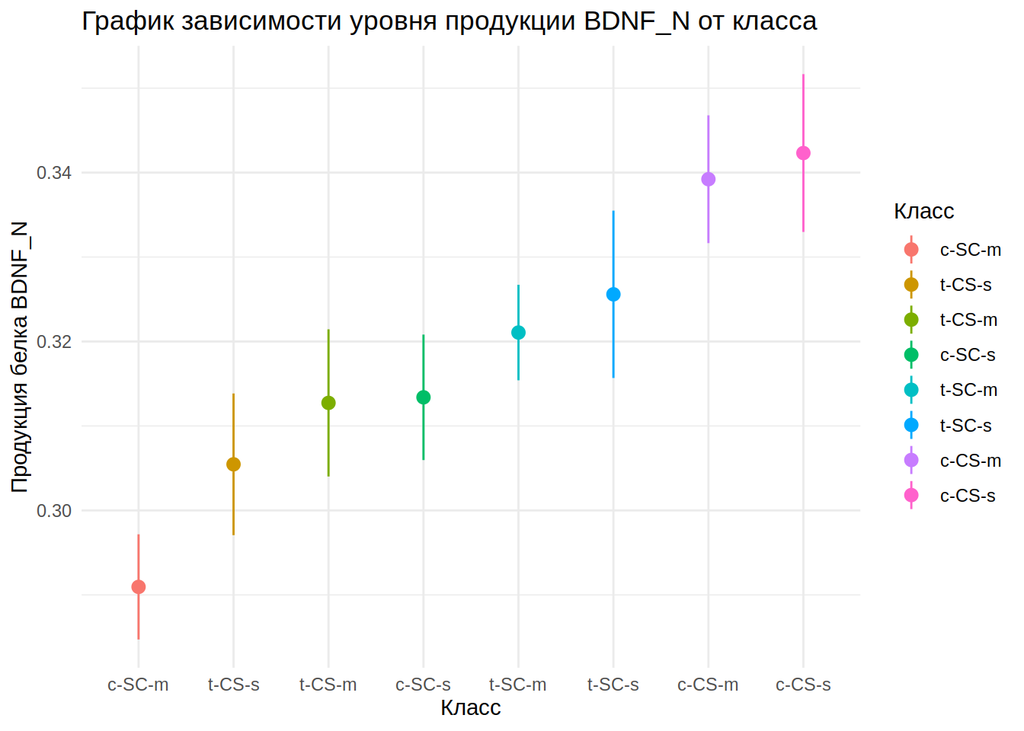

```r
anova_data$class <- reorder(anova_data$class, anova_data$BDNF_N, FUN = mean)
ggplot(data = anova_data, aes(x = class, y = BDNF_N, colour = class)) +
  stat_summary(geom = 'pointrange', fun.data = mean_cl_normal) + theme_minimal() +
  labs(x = "Класс", y = "Продукция белка BDNF_N", colour = 'Класс',
       title = "График зависимости уровня продукции BDNF_N от класса")
```

Подбираем коэффициенты модели в параметризации индикаторов:

```r
mod_treatment <- lm(BDNF_N ~ class, data = anova_data)
coef(mod_treatment)
```

```
## (Intercept) classt-CS-s classt-CS-m classc-SC-s classt-SC-m classt-SC-s
##  0.29094577  0.01451468  0.02178645  0.02244676  0.03011755  0.03464064
## classc-CS-m classc-CS-s
##  0.04827166  0.05136957
```

**Итерпретация полученных коэффициентов:**  
Первый коэффициент — это средняя продукция белка BDNF_N в классе с-SC-m (контрольных мышкй, нестимулированных к обучению, которых кололи мемантин) на базовом уровне.  
Другие коэффициенты — это разница продукции белка в других классах и в классе с-SC-m (отклонения от базового уровня).

Делаем дисперсионный анализ:  
Воспользуемся функцией *Anova()* из пакета **car**. Эта функция умеет тестировать влияние факторов в определенном порядке. Когда факторов будет больше одного, это станет важно для результатов, поэтому эту функцию нужно любить и жаловать!

```r
my_anova <- Anova(mod_treatment)
my_anova
```

```
## Anova Table (Type II tests)
##
## Response: BDNF_N
##            Sum Sq   Df F value    Pr(>F)
## class     0.28784    7  18.816 < 2.2e-16 ***
## Residuals 2.33619 1069
## ---
## Signif. codes:  0 '***' 0.001 '**' 0.01 '*' 0.05 '.' 0.1 ' ' 1
```

**Вывод:**  
Уровень продукции белка BDNF_N в зависимости от класса значимо отличается. F<sub>7</sub>, <sub>1069</sub> = 18.8, *p* < 0.01).

Результатам тестов можно верить, если выполняются условия применимости:  
Случайность и независимость наблюдений внутри групп,  
Нормальное распределение остатков,  
Гомогенность дисперсий остатков,  
Отсутствие коллинеарности факторов (независимость групп)

Также есть и другие ограничения:  
Лучше работает, если размеры групп примерно одинаковы (сбалансированный дисперсионный комплекс),  
Устойчив к отклонениям от нормального распределения (при равных объемах групп или при больших выборках)  
Отлично, вывод мы получили, однако можно ли ему верить? Проверим!

График расстояния Кука:

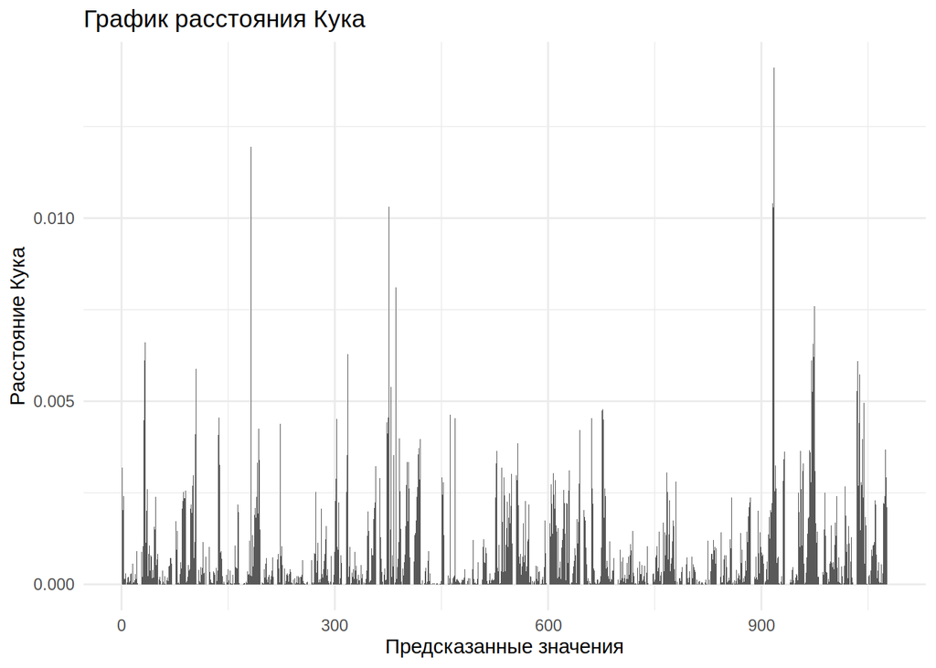

```r
mod_diag <- fortify(mod_treatment)
ggplot(mod_diag, aes(x = 1:nrow(mod_diag), y = .cooksd)) + geom_bar(stat = "identity") +
  labs(x = "Предсказанные значения", y = "Расстояние Кука", title = "График расстояния Кука") +
  theme_minimal()
```

Круто! Выбросов нет!

График остатков от предсказанных значений:

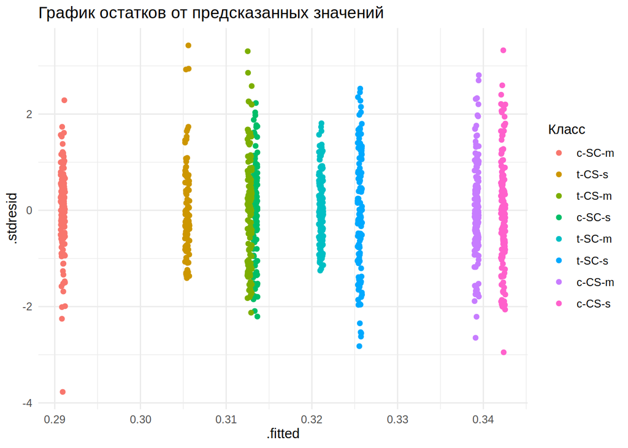

```r
ggplot(mod_diag, aes(x = .fitted, y = .stdresid, color = class)) + geom_jitter() + theme_minimal() +
  labs(colour = 'Класс', title = "График остатков от предсказанных значений")
```

Графики остатков от предикторов в модели и не в модели:

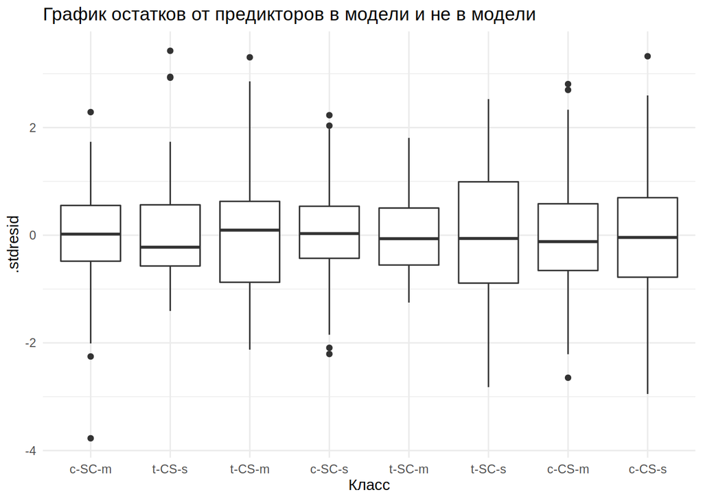

```r
ggplot(mod_diag, aes(x = class, y = .stdresid)) + geom_boxplot() + theme_minimal() +
  labs(x = "Класс", title = "График остатков от предикторов в модели и не в модели")
```

Дисперсии почти одинаковые…

Квантильный график остатков:

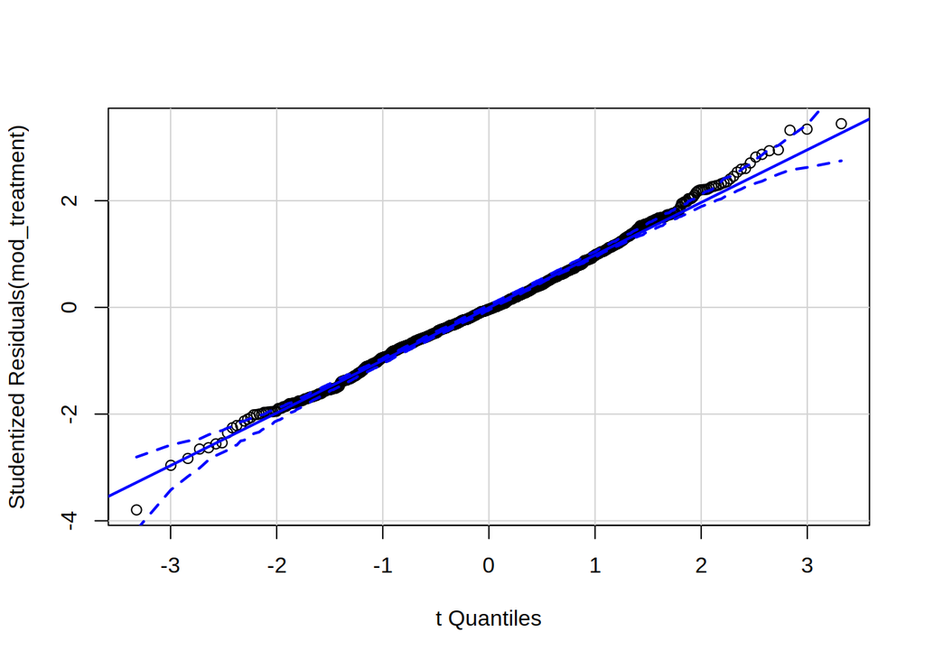

```r
qqPlot(mod_treatment, id = FALSE)
```

Выглядит вполне себе нормально!

Как понять, какие именно группы различаются?  
Дисперсионный анализ говорит нам только, есть ли влияние фактора, но не говорит, какие именно группы различаются. Коэффициенты линейной модели в **summary(mod_treatment)** содержат лишь часть ответа — сравнение средних значених всех групп со средним на базовом уровне. Если нас интересуют другие возможные попарные сравнения, нужно сделать пост хок тест.

Мы сделаем тест, основанный на распределении стьюдентизированного размаха: Тест Тьюки (Tuckey’s Honest Significant Difference, HSD).

```r
anova_ph <- glht(mod_treatment, linfct = mcp(class = "Tukey"))
summary(anova_ph)
```

```
##
##   Simultaneous Tests for General Linear Hypotheses
##
## Multiple Comparisons of Means: Tukey Contrasts
##
##
## Fit: lm(formula = BDNF_N ~ class, data = anova_data)
##
## Linear Hypotheses:
##                       Estimate Std. Error t value Pr(>|t|)
## t-CS-s - c-SC-m == 0 0.0145147  0.0059483   2.440   0.2228
## t-CS-m - c-SC-m == 0 0.0217865  0.0055459   3.928    <0.01 **
## c-SC-s - c-SC-m == 0 0.0224468  0.0055459   4.047    <0.01 **
## t-SC-m - c-SC-m == 0 0.0301176  0.0055459   5.431    <0.01 ***
## t-SC-s - c-SC-m == 0 0.0346406  0.0055790   6.209    <0.01 ***
## c-CS-m - c-SC-m == 0 0.0482717  0.0053980   8.942    <0.01 ***
## c-CS-s - c-SC-m == 0 0.0513696  0.0055459   9.263    <0.01 ***
## t-CS-m - t-CS-s == 0 0.0072718  0.0060829   1.195   0.9331
## c-SC-s - t-CS-s == 0 0.0079321  0.0060829   1.304   0.8972
## t-SC-m - t-CS-s == 0 0.0156029  0.0060829   2.565   0.1698
## t-SC-s - t-CS-s == 0 0.0201260  0.0061130   3.292   0.0227 *
## c-CS-m - t-CS-s == 0 0.0337570  0.0059483   5.675    <0.01 ***
## c-CS-s - t-CS-s == 0 0.0368549  0.0060829   6.059    <0.01 ***
## c-SC-s - t-CS-m == 0 0.0006603  0.0056900   0.116   1.0000
## t-SC-m - t-CS-m == 0 0.0083311  0.0056900   1.464   0.8259
## t-SC-s - t-CS-m == 0 0.0128542  0.0057223   2.246   0.3247
## c-CS-m - t-CS-m == 0 0.0264852  0.0055459   4.776    <0.01 ***
## c-CS-s - t-CS-m == 0 0.0295831  0.0056900   5.199    <0.01 ***
## t-SC-m - c-SC-s == 0 0.0076708  0.0056900   1.348   0.8797
## t-SC-s - c-SC-s == 0 0.0121939  0.0057223   2.131   0.3949
## c-CS-m - c-SC-s == 0 0.0258249  0.0055459   4.657    <0.01 ***
## c-CS-s - c-SC-s == 0 0.0289228  0.0056900   5.083    <0.01 ***
## t-SC-s - t-SC-m == 0 0.0045231  0.0057223   0.790   0.9936
## c-CS-m - t-SC-m == 0 0.0181541  0.0055459   3.273   0.0240 *
## c-CS-s - t-SC-m == 0 0.0212520  0.0056900   3.735    <0.01 **
## c-CS-m - t-SC-s == 0 0.0136310  0.0055790   2.443   0.2203
## c-CS-s - t-SC-s == 0 0.0167289  0.0057223   2.923   0.0688 .
## c-CS-s - c-CS-m == 0 0.0030979  0.0055459   0.559   0.9993
## ---
## Signif. codes:  0 '***' 0.001 '**' 0.01 '*' 0.05 '.' 0.1 ' ' 1
## (Adjusted p values reported -- single-step method)
```

Таблица результатов пост хок теста практически нечитабельна. Нужны графики!

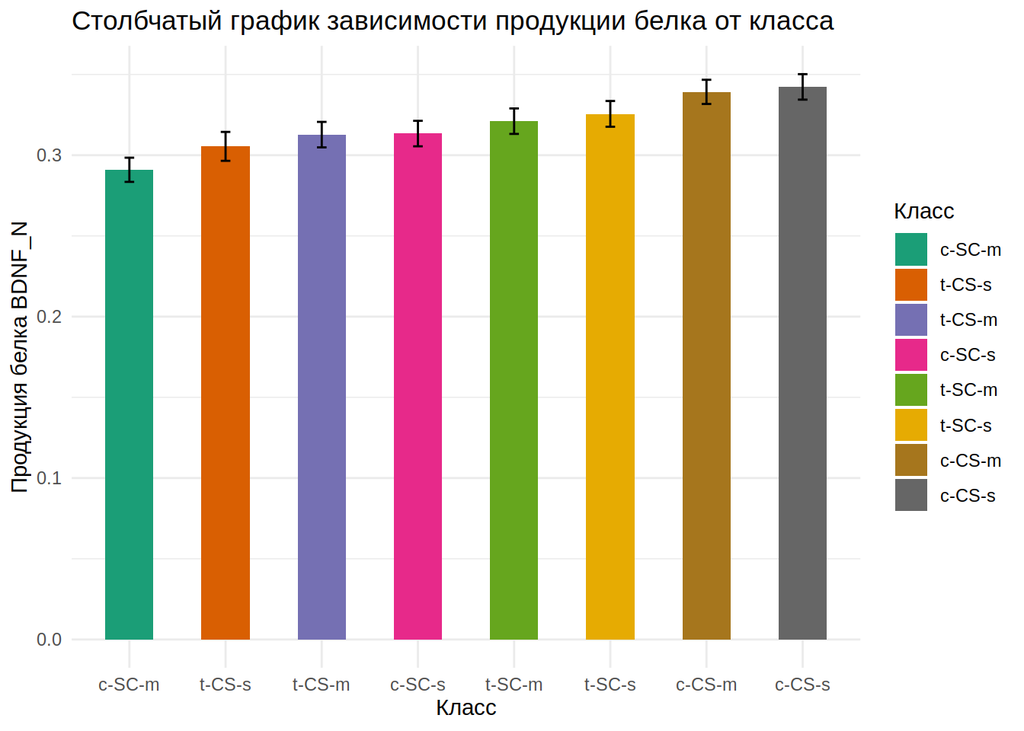

```r
MyData <- data.frame(class = factor(levels(anova_data$class), levels = levels(anova_data$class)))
MyData <- data.frame(MyData, predict(mod_treatment, newdata = MyData, interval = "confidence"))
X <- model.matrix(~class, data = MyData)
betas <- coef(mod_treatment)
MyData$fit <- X %*% betas
MyData$se <- sqrt(diag(X %*% vcov(mod_treatment) %*% t(X)))
t_crit <- qt(p = 0.975, df = nrow(anova_data) - length(coef(mod_treatment)))
MyData$lwr <- MyData$fit - t_crit * MyData$se
MyData$upr <- MyData$fit + t_crit * MyData$se

gg_bars <- ggplot(data = MyData, aes(x = class, y = fit)) +
  geom_bar(stat = "identity", aes(fill = class), width = 0.5) +
  geom_errorbar(aes(ymin = lwr, ymax = upr), width = 0.1) +
  labs(x = "Класс", y = "Продукция белка BDNF_N", title = "Столбчатый график зависимости продукции белка от класса") +
  scale_fill_brewer(name = "Класс", palette = "Dark2") +
  scale_x_discrete(labels = c("c-SC-m", "t-CS-s", "t-CS-m", "c-SC-s",
                              "t-SC-m", "t-SC-s", "c-CS-m", "c-CS-s")) +
  theme(legend.position = "none") + theme_minimal()
gg_bars
```

### Блок 3. Пробуем построить заведомо провальную линейную модель…

Прежде чем этим заняться, я бы хотела сразу объяснить, почему это изначально заведомо провальное решение:  
Модель продукции одного белка от всех других будет не соответствовать действительности, это можно сказать не глядя.  
1) Многие белки будут **коллинеарными** предикторами, что нарушает условие применимости анализа.  
2) Исходные даные **гетерогенны**, т.е. нельзя просто проанализировать зависимость белка от других белков, не включив в анализ факторы, задающие наши восемь классов.  
3) К тому же обычная lm не учтет структуру наших данных (есть **случайный фактор** особь).  
4) Даже GLMM нас не спасет, т.е. **из-за обилия предикторов будет переобучение**, вылезут в качестве значимых предикторов ложные корреляции (spurious correlations).  
5) Именно поэтому авторы статьи, обладающие достаточным количеством данных используют приемы машинного обучения, а не вот это все…

Что нам остается?

Делать lm не по белкам, а по компонентам после анализа главных компонент, в следующем блоке заданий мы именно этим и занимались, попробуем построить такую модель!  
Не переключайтесь, смотрите продолжене истории после анализа главных компонент!!!

### Блок 4. Анализ главных компонент

Для начала проведём неметрическое многомерное шкалирование или Nonmetric Multidimensional Scaling (nMDS) с использованием коэффициента различия Брея-Куртиса:  
Данный метод хорош тем, что старается сохранить отношения между объектами!  
nMDS **сохраняет ранг расстояний между объектами**, на ординации имеет смысл только взаиморасположение объектов. Облако точек в осях MDS можно вращать, перемещать, зеркально отражать. Суть ординации от этого не изменится, а значения координат точек в ординации лишены смысла (их вообще можно не приводить на итоговой ординации). Поехали!

```r
ord_data <- metaMDS(comm = good_data[, c(-1, -79:-85)],
                    distance = "bray", autotransform = FALSE)
```

```
## 'comm' has negative data: 'autotransform', 'noshare' and 'wascores' set to FALSE
```

```
## *** No convergence -- monoMDS stopping criteria:
##     11: stress ratio > sratmax
##      9: scale factor of the gradient < sfgrmin
```

```r
ord_data$stress
```

```
## [1] 0.1555072
```

Мы получили **стресс**, то есть меру качества ординации. Стресс показывает, насколько соответствуют друг другу взаиморасположение точек на плоскости ординации и в исходном многомерном пространстве признаков.

```r
ord_pt <- data.frame(good_data[, 79], scores(ord_data, display = "sites"))
g0 <- ggplot(ord_pt, aes(NMDS1, NMDS2, color = Genotype)) +
  geom_point()
```

```r
ord_pt <- data.frame(good_data[, 80], scores(ord_data, display = "sites"))
g1 <- ggplot(ord_pt, aes(NMDS1, NMDS2, color = Treatment)) +
  geom_point()
```

```r
ord_pt <- data.frame(good_data[, 81], scores(ord_data, display = "sites"))
g2 <- ggplot(ord_pt, aes(NMDS1, NMDS2, color = Behavior)) +
  geom_point()
```

```r
ord_pt <- data.frame(good_data[, 82], scores(ord_data, display = "sites"))
g3 <- ggplot(ord_pt, aes(NMDS1, NMDS2, color = class)) +
  geom_point()
```

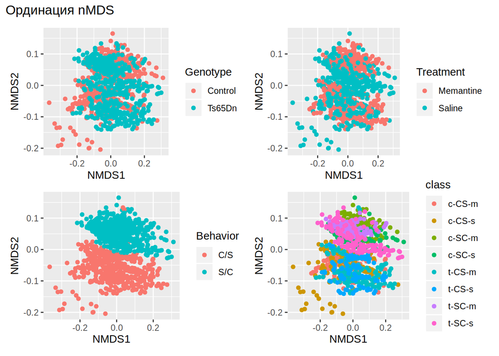

```r
plot_grid(g0, g1, g2, g3,
          ncol = 2, nrow = 2) + theme_minimal() + ggtitle(label = "Ординация nMDS")
```

Вау, видим, что по Behavior точки дажее неплохо расходятся!

Наконец, делаем PCA и знакомимся с тем, что у нас получилось:

```r
my_pca <- rda(good_data[, c(-1, -79:-85)], scale = TRUE)
head(summary(my_pca))
```

```
##
## Call:
## rda(X = good_data[, c(-1, -79:-85)], scale = TRUE)
##
## Partitioning of correlations:
##               Inertia Proportion
## Total              77          1
## Unconstrained      77          1
##
## Eigenvalues, and their contribution to the correlations
##
## Importance of components:
##                           PC1     PC2    PC3     PC4     PC5     PC6     PC7
## Eigenvalue            19.4965 13.4141 7.9266 5.76579 3.82453 3.53185 2.75704
## Proportion Explained   0.2532  0.1742 0.1029 0.07488 0.04967 0.04587 0.03581
## Cumulative Proportion  0.2532  0.4274 0.5304 0.60524 0.65490 0.70077 0.73658
##                           PC8     PC9    PC10    PC11    PC12    PC13    PC14
## Eigenvalue            2.34716 1.81952 1.31018 1.16805 0.94549 0.86350 0.82578
## Proportion Explained  0.03048 0.02363 0.01702 0.01517 0.01228 0.01121 0.01072
## Cumulative Proportion 0.76706 0.79069 0.80771 0.82288 0.83515 0.84637 0.85709
##                           PC15     PC16     PC17     PC18     PC19     PC20
## Eigenvalue            0.760809 0.677845 0.596688 0.584488 0.484679 0.452347
## Proportion Explained  0.009881 0.008803 0.007749 0.007591 0.006295 0.005875
## Cumulative Proportion 0.866974 0.875777 0.883527 0.891117 0.897412 0.903287
##                           PC21     PC22     PC23     PC24     PC25     PC26
## Eigenvalue            0.430775 0.421417 0.399832 0.370649 0.358646 0.341992
## Proportion Explained  0.005594 0.005473 0.005193 0.004814 0.004658 0.004441
## Cumulative Proportion 0.908881 0.914354 0.919547 0.924360 0.929018 0.933459
##                           PC27     PC28     PC29     PC30    PC31     PC32
## Eigenvalue            0.311475 0.310412 0.263066 0.245394 0.23174 0.219830
## Proportion Explained  0.004045 0.004031 0.003416 0.003187 0.00301 0.002855
## Cumulative Proportion 0.937505 0.941536 0.944952 0.948139 0.95115 0.954004
##                           PC33     PC34     PC35     PC36     PC37     PC38
## Eigenvalue            0.211326 0.200590 0.174475 0.165846 0.160607 0.155296
## Proportion Explained  0.002744 0.002605 0.002266 0.002154 0.002086 0.002017
## Cumulative Proportion 0.956748 0.959353 0.961619 0.963773 0.965859 0.967876
##                          PC39     PC40     PC41    PC42     PC43     PC44
## Eigenvalue            0.15012 0.142811 0.128470 0.12786 0.117245 0.113105
## Proportion Explained  0.00195 0.001855 0.001668 0.00166 0.001523 0.001469
## Cumulative Proportion 0.96983 0.971680 0.973348 0.97501 0.976532 0.978000
```

[output cut: 38 more lines]

```
## NR2A_N   -1.5582  0.6529 -0.1787 -0.60253 -0.01300 -0.17696
## pAKT_N   -1.0154 -1.0976  0.4847  0.55016  0.39568  0.45233
## ....
##
##
## Site scores (weighted sums of species scores)
##
##           PC1    PC2    PC3     PC4    PC5      PC6
## sit1 -0.54722 0.7571 0.3798 -0.4649 0.2656 -0.21733
## sit2 -0.35823 0.7698 0.2050 -0.3397 0.1987 -0.13225
## sit3 -0.37194 0.7986 0.1617 -0.2620 0.2012 -0.06602
## sit4 -0.07902 0.5604 0.5103 -0.2082 0.3804 -0.11306
## sit5  0.04415 0.6073 0.2919 -0.1120 0.3108 -0.05312
## sit6  0.04358 0.6365 0.3309 -0.1296 0.4126  0.02101
## ....
```

Что важного есть в summary:  
1) Eigenvalues (собственные числа)  
Собственные числа показывают дисперсию вдоль осей, заданных собственными векторами. По значениям собственных чисел можно вычислить долю общей изменчивости, связанной с каждой из главных компонент.  
2) Eigenvectors (собственные векторы, факторные нагрузки)

Собственные векторы задают главные компоненты — направления новых осей. Они также называются факторными нагрузками, т.к. это линейные комбинации исходных признаков.

Могут быть рассчитаны как для признаков (Species scores), так и для объектов (Site scores).

Графики ординации:

Биплот с симметричным шкалированием:

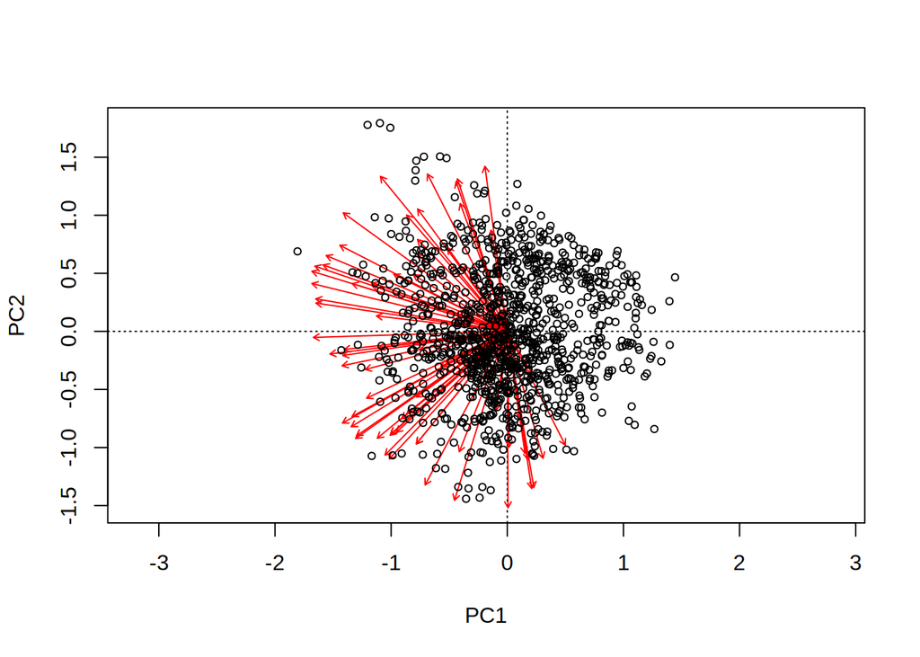

```r
biplot(my_pca)
```

Такой график отражает одновременно и признаки и объекты. Но его нельзя интерпретировать.

Биплот корреляций (график нагрузок):

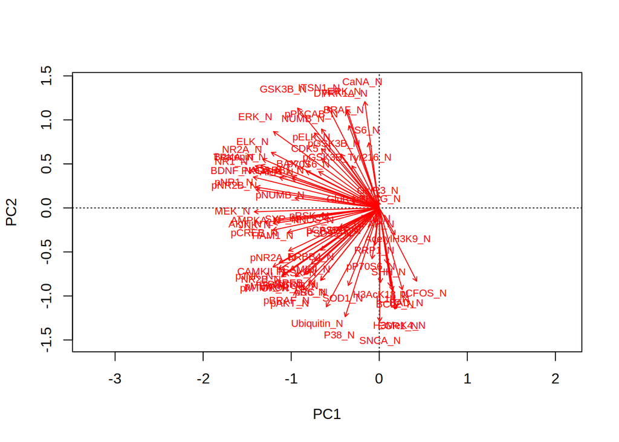

```r
biplot(my_pca, scaling = "species", display = "species")
```

Биплот расстояний (график ординации):

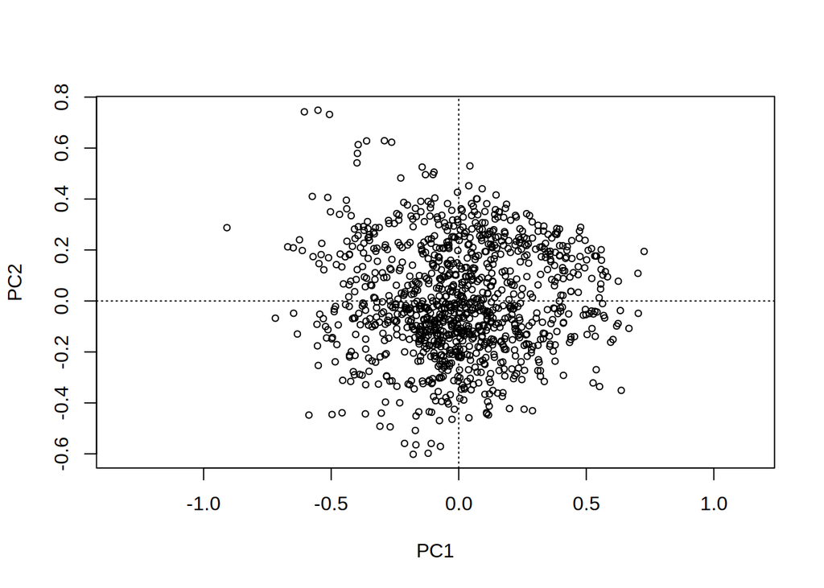

```r
biplot(my_pca, scaling = "sites", display = "sites")
```

График ординации помощью **ggplot2** в осях первых двух главных компонент:

```r
df_scores <- data.frame(good_data,
                        scores(my_pca, display = "sites", choices = c(1, 2, 3), scaling = "sites"))

gg1 <- ggplot(df_scores, aes(x = PC1, y = PC2)) +
  geom_point(aes(color = Genotype), alpha = 0.5) +
  coord_equal(xlim = c(-1.2, 1.2), ylim = c(-1.2, 1.2)) + theme_minimal()
```

```r
gg2 <- ggplot(df_scores, aes(x = PC1, y = PC2)) +
  geom_point(aes(color = Treatment), alpha = 0.5) +
  coord_equal(xlim = c(-1.2, 1.2), ylim = c(-1.2, 1.2)) + theme_minimal()
```

```r
gg3 <- ggplot(df_scores, aes(x = PC1, y = PC2)) +
  geom_point(aes(color = Behavior), alpha = 0.5) +
  coord_equal(xlim = c(-1.2, 1.2), ylim = c(-1.2, 1.2)) + theme_minimal()
```

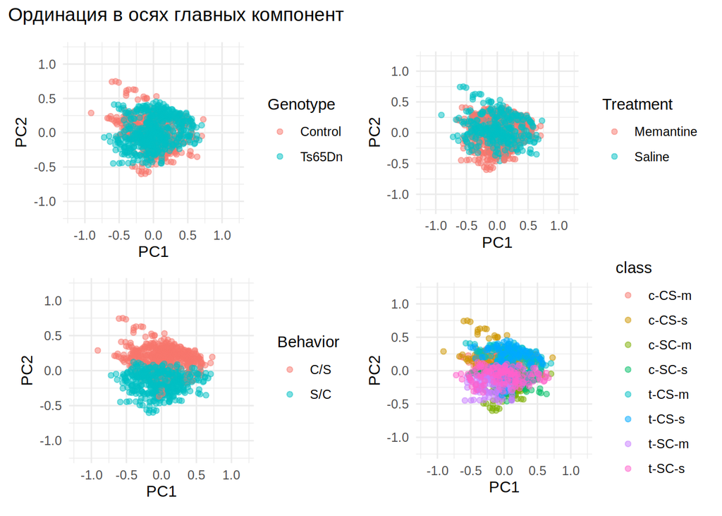

```r
gg4 <- ggplot(df_scores, aes(x = PC1, y = PC2)) +
  geom_point(aes(color = class), alpha = 0.5) +
  coord_equal(xlim = c(-1.2, 1.2), ylim = c(-1.2, 1.2)) + theme_minimal()

plot_grid(gg1, gg2, gg3, gg4,
          ncol = 2, nrow = 2) + theme_minimal() + ggtitle(label = "Ординация в осях главных компонент")
```

Интерпретация PCA:  
В самом начале необходимо понять, какой вклад вносит каждая компонента. Для этого есть условные коэффициенты, а также это можно проанализировать с использованием графика собственных чисел:

```r
eigenvals(my_pca)
```

```
##       PC1       PC2       PC3       PC4       PC5       PC6       PC7       PC8
## 19.496549 13.414127  7.926640  5.765787  3.824529  3.531849  2.757043  2.347163
##       PC9      PC10      PC11      PC12      PC13      PC14      PC15      PC16
##  1.819520  1.310180  1.168051  0.945487  0.863504  0.825781  0.760809  0.677845
##      PC17      PC18      PC19      PC20      PC21      PC22      PC23      PC24
##  0.596688  0.584488  0.484679  0.452347  0.430775  0.421417  0.399832  0.370649
##      PC25      PC26      PC27      PC28      PC29      PC30      PC31      PC32
##  0.358646  0.341992  0.311475  0.310412  0.263066  0.245394  0.231739  0.219830
##      PC33      PC34      PC35      PC36      PC37      PC38      PC39      PC40
##  0.211326  0.200590  0.174475  0.165846  0.160607  0.155296  0.150115  0.142811
##      PC41      PC42      PC43      PC44      PC45      PC46      PC47      PC48
##  0.128470  0.127858  0.117245  0.113105  0.108354  0.102274  0.099051  0.093923
##      PC49      PC50      PC51      PC52      PC53      PC54      PC55      PC56
##  0.091494  0.087412  0.080114  0.077435  0.074244  0.070769  0.066045  0.060133
##      PC57      PC58      PC59      PC60      PC61      PC62      PC63      PC64
##  0.056895  0.053676  0.052390  0.049899  0.048527  0.047365  0.042347  0.038521
##      PC65      PC66      PC67      PC68      PC69      PC70      PC71      PC72
##  0.037015  0.036443  0.034747  0.030964  0.027646  0.024993  0.023896  0.019783
##      PC73      PC74      PC75      PC76
##  0.016347  0.015360  0.014818  0.011082
```

```r
bstick(my_pca)
```

```
##        PC1        PC2        PC3        PC4        PC5        PC6        PC7
## 4.97917818 3.96602028 3.45944133 3.12172204 2.86843256 2.66580098 2.49694133
##        PC8        PC9       PC10       PC11       PC12       PC13       PC14
## 2.35220449 2.22555976 2.11298666 2.01167087 1.91956560 1.83513578 1.75720056
##       PC15       PC16       PC17       PC18       PC19       PC20       PC21
## 1.68483214 1.61728828 1.55396591 1.49436838 1.43808183 1.38475773 1.33409984
##       PC22       PC23       PC24       PC25       PC26       PC27       PC28
## 1.28585423 1.23980159 1.19575125 1.15353634 1.11301002 1.07404241 1.03651805
##       PC29       PC30       PC31       PC32       PC33       PC34       PC35
## 1.00033383 0.96539736 0.93162543 0.89894291 0.86728173 0.83657997 0.80678121
##       PC36       PC37       PC38       PC39       PC40       PC41       PC42
## 0.77783384 0.74969057 0.72230792 0.69564587 0.66966747 0.64433852 0.61962735
##       PC43       PC44       PC45       PC46       PC47       PC48       PC49
## 0.59550454 0.57194273 0.54891642 0.52640180 0.50437663 0.48282007 0.46171262
##       PC50       PC51       PC52       PC53       PC54       PC55       PC56
## 0.44103593 0.42077277 0.40090693 0.38142312 0.36230693 0.34354475 0.32512370
##       PC57       PC58       PC59       PC60       PC61       PC62       PC63
## 0.30703159 0.28925689 0.27178865 0.25461649 0.23773052 0.22112138 0.20478012
##       PC64       PC65       PC66       PC67       PC68       PC69       PC70
## 0.18869825 0.17286766 0.15728061 0.14192973 0.12680797 0.11190859 0.09722515
##       PC71       PC72       PC73       PC74       PC75       PC76
## 0.08275146 0.06848163 0.05441000 0.04053112 0.02683980 0.01333102
```

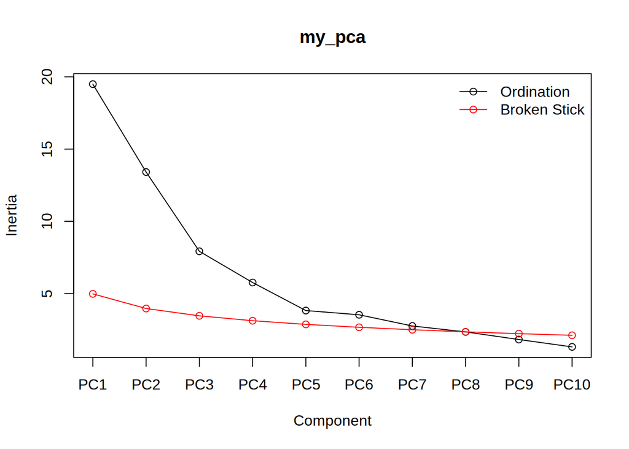

```r
screeplot(my_pca, type = "lines", bstick = TRUE)
```

Другим простым способом для объяснения того, какой вклад вносит та или иная компонента – посмотреть в summary() **Proportion Explained**. Это можно визуализировать:

[figure not shown]

```r
pca_summary <- summary(my_pca)
pca_result <- as.data.frame(pca_summary$cont)
plot_data <- as.data.frame(t(pca_result[c("Proportion Explained"), ]))
plot_data$component <- rownames(plot_data)

ggplot(plot_data, aes(component, `Proportion Explained`)) +
  geom_bar(stat = "identity") + theme_minimal()
```

Интерпретация компонент:  
Факторные нагрузки оценивают вклады переменных в изменчивость по главной компоненте:  
1) модуль значения нагрузки — величина вклада  
2) знак значения нагрузки — направление вклада

```r
scores(my_pca, display = "species", choices = c(1, 2, 3), scaling = 0)
```

```
##                           PC1         PC2         PC3
## DYRK1A_N        -0.0515535421  0.18189064  0.11449120
## ITSN1_N         -0.0803567646  0.19111062  0.08009097
## BDNF_N          -0.1968525349  0.05816419  0.06931960
## NR1_N           -0.1968198040  0.07303260 -0.04000666
## NR2A_N          -0.1823965406  0.09213023 -0.03280984
## pAKT_N          -0.1188612118 -0.15489827  0.08897311
## pBRAF_N         -0.1231183566 -0.15019950  0.11373378
## pCAMKII_N       -0.1010005160 -0.09967638 -0.04293235
## pCREB_N         -0.1664141054 -0.04172735 -0.01385182
## pELK_N          -0.0904606005  0.11165102  0.13409810
## pERK_N          -0.0502249604  0.18521056  0.10670870
## pJNK_N          -0.1660755341 -0.11136904  0.01288368
## PKCA_N          -0.1562384224  0.05801869  0.09866511
## pMEK_N          -0.1519312358 -0.12689677  0.07863808
## pNR1_N          -0.1929263077  0.03950332 -0.04855171
## pNR2A_N         -0.1416782539 -0.08113681 -0.12425881
## pNR2B_N         -0.1927709346  0.03436447 -0.07886284
## pPKCAB_N        -0.0902976553  0.14862963  0.08088707
## pRSK_N          -0.0936236788 -0.01467932  0.07250186
## AKT_N           -0.1786862642 -0.02748043 -0.04994678
## BRAF_N          -0.0473909011  0.15517183  0.14391950
## CAMKII_N        -0.1564071852 -0.10341358  0.11634029
## CREB_N          -0.1117084484 -0.12246159  0.14390373
## ELK_N           -0.1686397495  0.10458049 -0.08927270
## ERK_N           -0.1652636157  0.14398835 -0.05477113
## GSK3B_N         -0.1278198023  0.18832941  0.07284531
## JNK_N           -0.1657191124 -0.02925885  0.10916979
## MEK_N           -0.1953923092 -0.00729440  0.03096548
## TRKA_N          -0.1937865214  0.07925605 -0.02822248
## RSK_N           -0.1063838821 -0.10608903  0.14252388
## APP_N           -0.1363060085  0.05568602  0.07726268
## Bcatenin_N      -0.1855690107  0.08072392 -0.07577415
## SOD1_N          -0.0483974285 -0.14609489 -0.10245571
## MTOR_N          -0.1309426154 -0.12973314  0.09197198
## P38_N           -0.0532093550 -0.20513597  0.04512425
## pMTOR_N         -0.1528463901 -0.13000926  0.01522354
## DSCR1_N         -0.1172035058 -0.12445829  0.15493698
## AMPKA_N         -0.1644124456 -0.02197860  0.10752758
## NR2B_N          -0.1572567072 -0.11583139  0.06630259
```

[output cut: 25 more lines]

```
## SNCA_N           0.0007405069 -0.21412535 -0.03499664
## Ubiquitin_N     -0.0827366049 -0.18643885 -0.10819383
## pGSK3B_Tyr216_N -0.0426881010  0.07930584 -0.11092945
## SHH_N            0.0122441269 -0.10430173 -0.07336561
## BAD_N            0.0360361093 -0.15408344  0.07792180
## BCL2_N           0.0206908413 -0.15573267  0.07122090
## pS6_N           -0.0915392611 -0.13659720 -0.21164433
## pCFOS_N          0.0584110547 -0.13806722  0.03089784
## SYP_N           -0.1295494552 -0.01980617 -0.13337806
## H3AcK18_N        0.0019370649 -0.14048578  0.00219530
## EGR1_N           0.0245912415 -0.19077178  0.01510242
## H3MeK4_N         0.0267089519 -0.18973020  0.02103771
## CaNA_N          -0.0225245792  0.20050387 -0.01783429
## attr(,"const")
## [1] 16.97767
```

Для каждой компоненты:  
Высокие положительные нагрузки по главным компонентам у переменных значат, чем *больше* значение компоненты, тем больше продукция белка.  
Высокие отрицательные нагрузки у переменных значат, чем меньше значение компоненты, тем *больше* продукция.

На последок еще одна визуализация PCA:

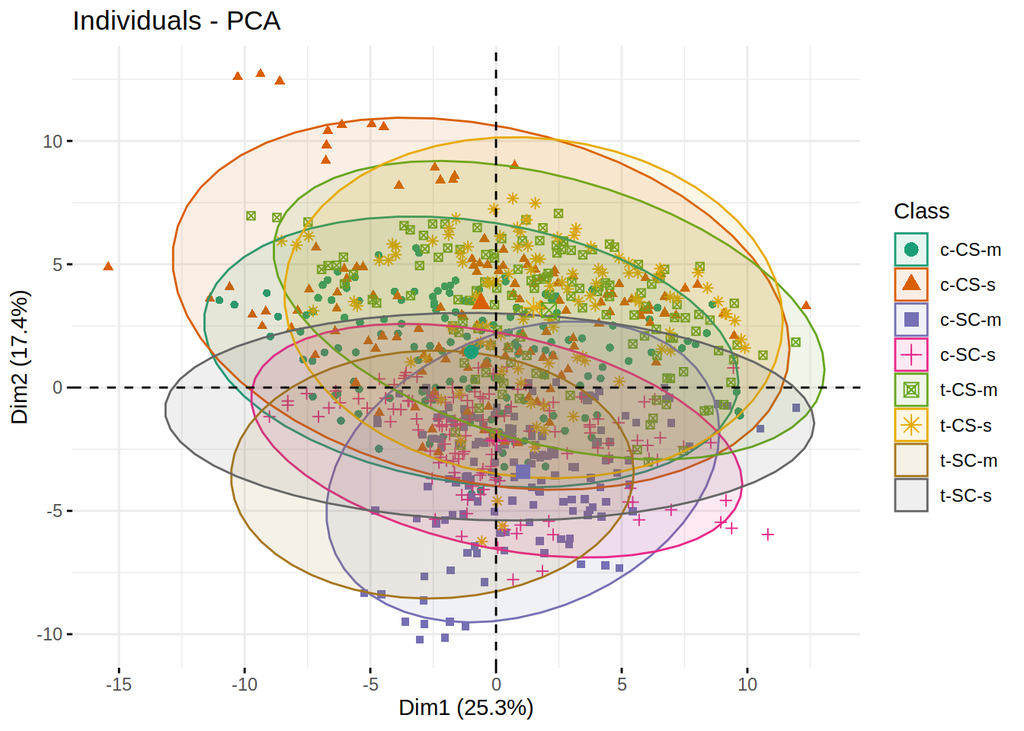

```r
pca_base <- prcomp(good_data[, c(-1, -79:-85)], scale = TRUE)
fviz_pca_ind(pca_base,
             geom.ind = "point", # show points only (nbut not "text")
             col.ind = good_data$`data$class`, # color by groups
             palette = "Dark2",
             addEllipses = TRUE, # Concentration ellipses
             legend.title = "Class"
             )
```

Окончательная красота c 3D визуализацией:

```r
pca3d(pca_base, group=good_data$`data$class`)
```

```
## [1] 0.3085552 0.2541783 0.2010811
## Creating new device
```

##### Возвращаемся к истории с линейной моделью

Теперь мы вооружены всеми данными с анализа главных компонент и можем снова вернуться к **lm**.  
Создаем наш маленький датафрейм для анализа:

```r
protein <- good_data$ERBB4_N
pca1 <- pca_base$rotation[, 1]
pca2 <- pca_base$rotation[, 2]
pca3 <- pca_base$rotation[, 3]
pca4 <- pca_base$rotation[, 4]
pca5 <- pca_base$rotation[, 5]
pca6 <- pca_base$rotation[, 6]
pca7 <- pca_base$rotation[, 7]
pca8 <- pca_base$rotation[, 8]
pca9 <- pca_base$rotation[, 9]
lm_data <- as.data.frame(cbind(protein, pca1, pca2, pca3, pca4, pca5, pca6, pca7, pca8, pca9))
```

##### Строим модель:

```r
mod1 <- lm(protein ~ ., data = lm_data)
```

##### Анализ полученной модели:

1. Проверка на линейность взаимосвязи с помощью графика остатков предсказанных значений:

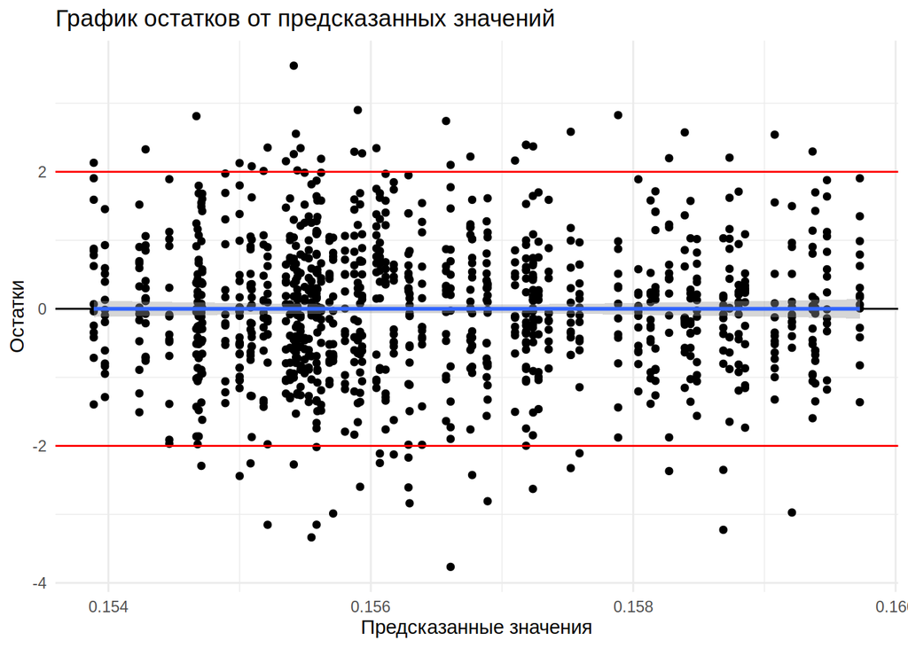

```r
mod1_diag <- fortify(mod1)
gg_resid_1 <- ggplot(data = mod1_diag, aes(x = .fitted, y = .stdresid)) +
  geom_point() +
  geom_hline(yintercept = 0) +
  geom_smooth(method = "lm") +
  geom_hline(yintercept = 2, color = "red") +
  geom_hline(yintercept = -2, color = "red") +
  theme_minimal()
gg_resid_2 <- gg_resid_1 + labs(x = "Предсказанные значения", y = "Остатки", title = "График остатков от предсказанных значений")
gg_resid_2
```

Выглядит боле менее равномерно, однако далеко от идеала!

2. Проверка влиятельных наблюдений с помощью графика расстояний Кука:

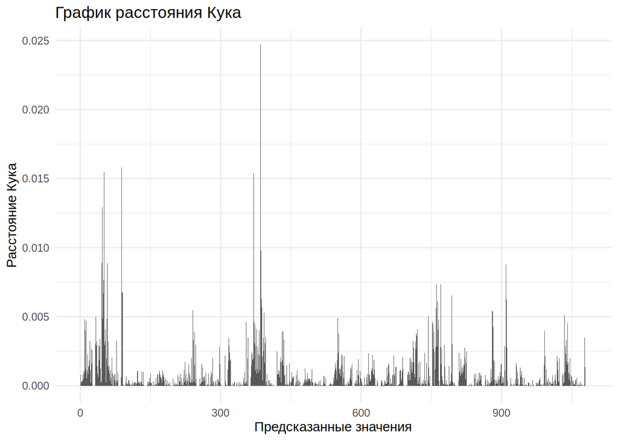

Все хорошо, влиятельные наблюдения отсутствуют!

3. Нормальность распределения остатков:

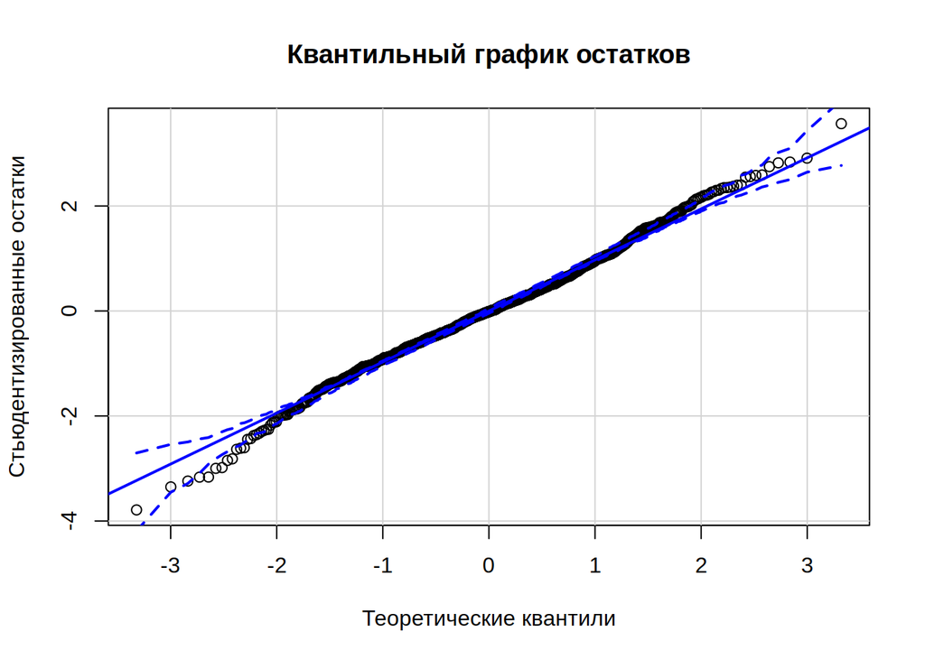

Можно сказать, что остатки распределены даже более менее нормально!

Посмотрим на график остатков от предикторов, вошедших в данную модель:

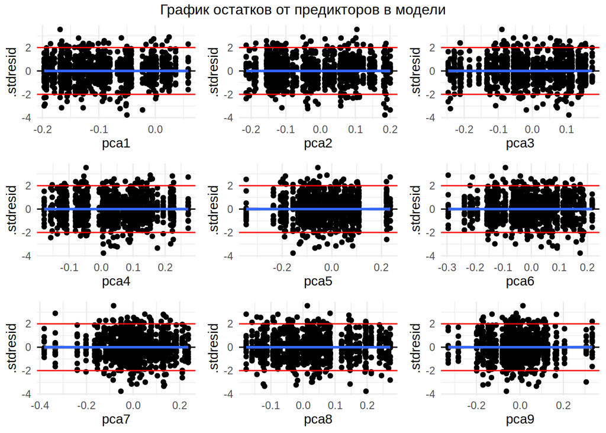

Четких нелинейных паттерном на данных графиках я не вижу, что заставляет задуматься, что, возможно, все не так плохо, как мы изначально предполагали…

Наконец, ознакомимя с саммари модели:

```
##
## Call:
## lm(formula = protein ~ ., data = lm_data)
##
## Residuals:
##       Min        1Q    Median        3Q       Max
## -0.056391 -0.009164 -0.000202  0.008723  0.053285
##
## Coefficients:
##               Estimate Std. Error t value Pr(>|t|)
## (Intercept)  0.1544816  0.0020127  76.753   <2e-16 ***
## pca1        -0.0081165  0.0146247  -0.555   0.5790
## pca2        -0.0064322  0.0051854  -1.240   0.2151
## pca3        -0.0052621  0.0042345  -1.243   0.2143
## pca4         0.0113010  0.0070560   1.602   0.1095
## pca5        -0.0110718  0.0064203  -1.725   0.0849 .
## pca6         0.0003204  0.0041583   0.077   0.9386
## pca7         0.0042618  0.0040408   1.055   0.2918
## pca8         0.0080671  0.0062325   1.294   0.1958
## pca9        -0.0037777  0.0043490  -0.869   0.3852
## ---
## Signif. codes:  0 '***' 0.001 '**' 0.01 '*' 0.05 '.' 0.1 ' ' 1
##
## Residual standard error: 0.01506 on 1070 degrees of freedom
## Multiple R-squared:  0.01007,    Adjusted R-squared:  0.001746
## F-statistic:  1.21 on 9 and 1070 DF,  p-value: 0.2849
```

Наибольший по модулю коэффициент обладает переменная **pca4**. Построим от нее график предсказания стоимости:

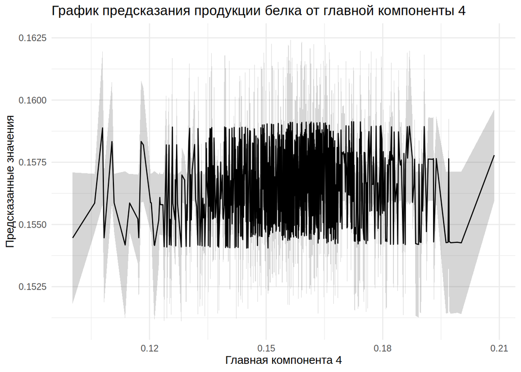

Отличный способ проиллюстрировать, что не надо строить линейные модели от чего попало и не учитывать важные группирующие факторы в модели. ВСЕ! :>

### Блок 5. Magic fantasy. Дифференциальная экспрессия…